# R Notebook

# Exercise Sheet 1

## Ex1

A call centre receives calls according to a Poisson process. The expected number of calls it receives in a day is 1523. On any given day, the call centre has enough staff to cope with a maximum of 1600 calls. What is the probability that on any given day the call centre receives more calls than it can cope with.

```r
lambda = 1523
1 - ppois(1600, lambda)
```

```
[1] 0.02421278
```

## Ex2

Write code that simulates a homogeneous temporal Poisson process on $(0, T]$ with intensity λ. Have a go at writing it as a function homogeneouspp(lambda,T), such that it can take any value of λ and T that you wish to give it.

```r
homogeneouspp = function(lambda, T) {
  N = rpois(1, lambda * T)
  E = runif(N, min = 0, max = T)
  E = sort(E)
  return(E)
}
```

Simulate 100 realisations of a Poisson process on (0, 10] with intensity λ = 10.

```r
all_simu = list()
for (i in 1:100) {
  N = homogeneouspp(10, 10)
  all_simu[[i]] = N
}
```

1. Verify that the sample mean number of events in the interval (3, 5] is consistent with the expected number of events in (3, 5].

```r
sum = 0
for (i in 1:100) {
  one_sim = all_simu[[i]]
  sum = sum + length(one_sim[one_sim > 3 & one_sim <= 5])
}

sum / 100
```

```
[1] 20.62
```

The expected number of events in $(3, 5]$ is the $\lambda$ for the poisson distribution $\text{Poisson}(20)$ which is $20$.

2. Plot a histogram for the 100 realisations of the number of events N {(2, 8]}

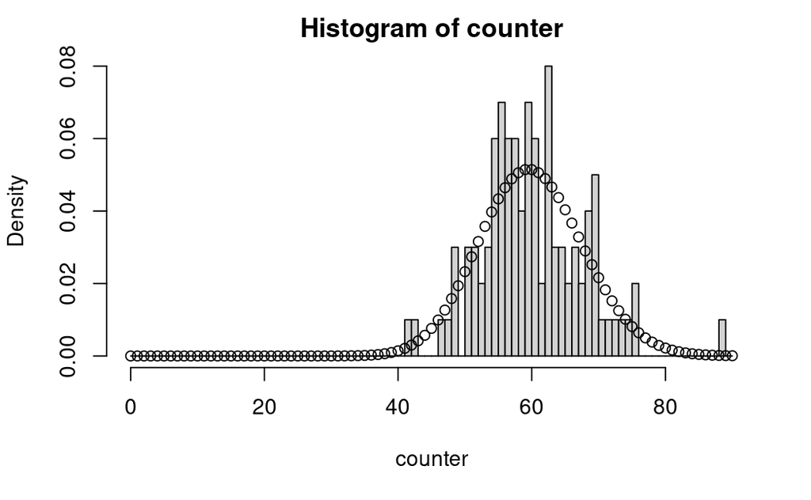

```r
counter = sapply(all_simu, function(x) {
  return(length(x[x > 2 & x <= 8]))
})

hist(counter, freq = F, breaks = seq(0, 90, 1))
points(seq(0,90,1),dpois(seq(0,90,1),60))
```

```r
count1 = sapply(all_simu, function(x) {
  return(length(x[x > 2 & x <= 5]))
})

count2 = sapply(all_simu, function(x) {
  return(length(x[x > 6 & x <= 8]))
})

rho = cor(count1, count2)
rho
```

```
[1] -0.2060393
```